# my title

hello: this is a markdown chunk with some notes

```python
import pandas
import matplotlib.pyplot as plt
```

```python
dat_file = '../data/dna.example.lengths.tsv'

# read_csv returns an object of class DataFrame
df = pandas.read_csv(dat_file,sep = '\t')

print("here's the first few rows of %s" % dat_file)
display(df[0:6])
```

```
here's the first few rows of ../data/dna.example.lengths.tsv
```

|  | SeqID | Length |
| --- | --- | --- |
| 0 | gi\|142022655\|gb\|EQ086233.1\|43 | 990 |
| 1 | gi\|142022655\|gb\|EQ086233.1\|160 | 724 |
| 2 | gi\|142022655\|gb\|EQ086233.1\|41 | 3080 |
| 3 | gi\|142022655\|gb\|EQ086233.1\|221 | 2863 |
| 4 | gi\|142022655\|gb\|EQ086233.1\|294 | 3832 |
| 5 | gi\|142022655\|gb\|EQ086233.1\|323 | 4805 |

# use matplot lib to make a histogram

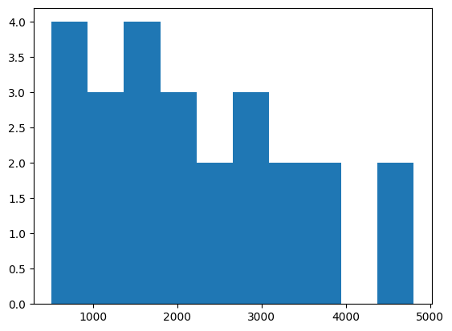

```python
numbins = 10
plt.hist(df["Length"], numbins)
plt.show()
```

I could explore the [`matplotlib` package](https://matplotlib.org) more to understand how to make plots within python, and the related package seaborn. But why, when I'm happy in R?

# Jupyter notebook features:

'Variables' viewer: click "variables" in the top bar, and a browser window appears at the bottom. For some of our variables (like `DataFrame` objects) we can double-click, and a new viewer window pops up so that we can browse the actual data, with sorting and filtering functions. Similar to Rstudio. More info [here](https://code.visualstudio.com/docs/datascience/data-science-tutorial#_prepare-the-data)

[Debugging](https://code.visualstudio.com/docs/datascience/jupyter-notebooks#_run-by-line): hovering over a python cell shows a menu on the top right. The first item here is the 'run by line' button. Click once to enter debug mode, click again to run the next line. Debug console allows us to explore the data at each point. There are more sophisticated ways to do this, e.g. by 'inserting breakpoints' in the code, and using the 'debug cell' option (next to the 'run' button, on the left of the cell): here, it runs through the code and pauses at the breakpoints.

Running code remotely - can use the kernel picker to connect to a Jupyter server

The ipynb is actually a JSON file that contains all the markdown, code, results and plots etc. It renders nicely when displayed via github. I think I need to click 'run all' when I change code, to make sure the output is updated.

Export: can export as Python file (.py), a PDF (if TEX is installed), or an HTML file. To export, select the Export action on the main toolbar.